# week 10 day 2 HW

Peter Menzies

06/01/2021

```r
library(tidyverse)
```

# MVP

#### 1

```r
diamonds_data <- read_csv("diamonds.csv")
head(diamonds_data)
```

```
## # A tibble: 6 x 11
##      X1 carat cut       color clarity depth table price     x     y     z
##   <dbl> <dbl> <chr>     <chr> <chr>   <dbl> <dbl> <dbl> <dbl> <dbl> <dbl>
## 1     1 0.23  Ideal     E     SI2      61.5    55   326  3.95  3.98  2.43
## 2     2 0.21  Premium   E     SI1      59.8    61   326  3.89  3.84  2.31
## 3     3 0.23  Good      E     VS1      56.9    65   327  4.05  4.07  2.31
## 4     4 0.290 Premium   I     VS2      62.4    58   334  4.2   4.23  2.63
## 5     5 0.31  Good      J     SI2      63.3    58   335  4.34  4.35  2.75
## 6     6 0.24  Very Good J     VVS2     62.8    57   336  3.94  3.96  2.48
```

```r
summary(diamonds_data)
```

```
##        X1            carat            cut               color
##  Min.   :    1   Min.   :0.2000   Length:53940       Length:53940
##  1st Qu.:13486   1st Qu.:0.4000   Class :character   Class :character
##  Median :26970   Median :0.7000   Mode  :character   Mode  :character
##  Mean   :26970   Mean   :0.7979
##  3rd Qu.:40455   3rd Qu.:1.0400
##  Max.   :53940   Max.   :5.0100
##    clarity              depth           table           price
##  Length:53940       Min.   :43.00   Min.   :43.00   Min.   :  326
##  Class :character   1st Qu.:61.00   1st Qu.:56.00   1st Qu.:  950
##  Mode  :character   Median :61.80   Median :57.00   Median : 2401
##                     Mean   :61.75   Mean   :57.46   Mean   : 3933
##                     3rd Qu.:62.50   3rd Qu.:59.00   3rd Qu.: 5324
##                     Max.   :79.00   Max.   :95.00   Max.   :18823
##        x                y                z
##  Min.   : 0.000   Min.   : 0.000   Min.   : 0.000
##  1st Qu.: 4.710   1st Qu.: 4.720   1st Qu.: 2.910
##  Median : 5.700   Median : 5.710   Median : 3.530
##  Mean   : 5.731   Mean   : 5.735   Mean   : 3.539
##  3rd Qu.: 6.540   3rd Qu.: 6.540   3rd Qu.: 4.040
##  Max.   :10.740   Max.   :58.900   Max.   :31.800
```

#### 2

```r
library(GGally)
```

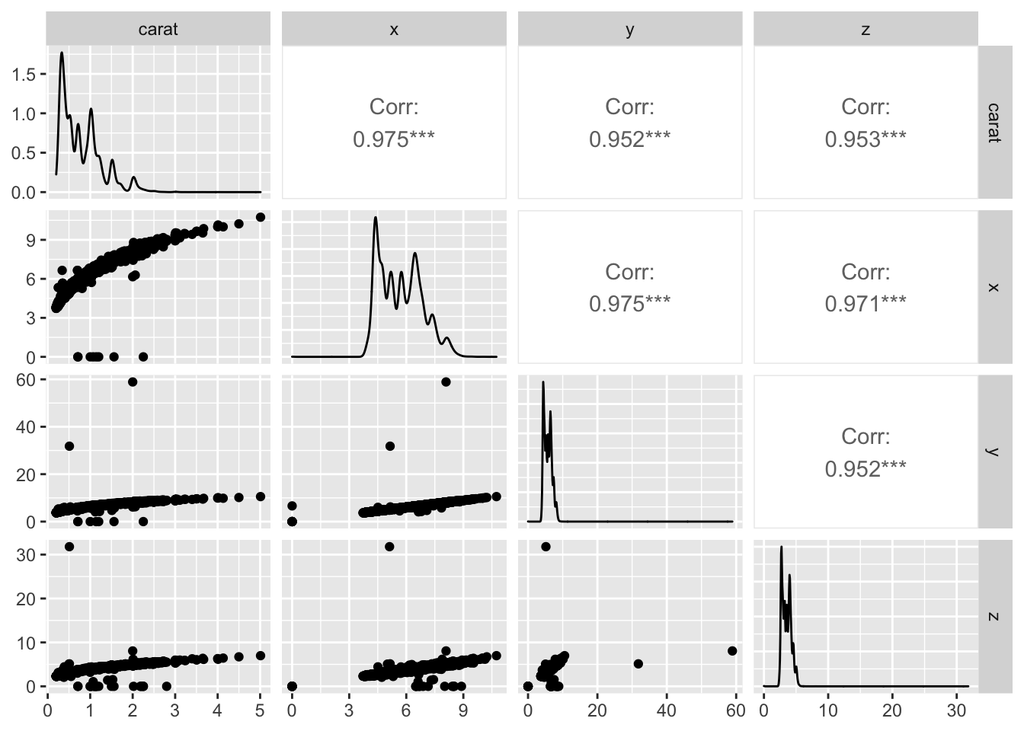

```r
diamonds_data %>%
  select(carat, x, y, z) %>%
  ggpairs()
```

#### 3

```r
diamonds_working <- diamonds_data %>%
  select(-x, -y, -z, -X1)
```

#### 4

###### i

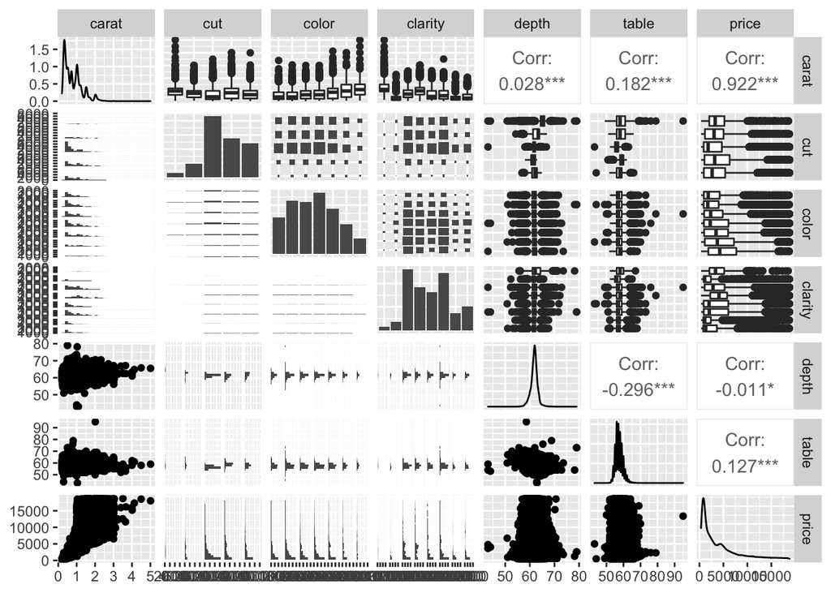

```r
ggpairs(diamonds_working)
```

##### ii

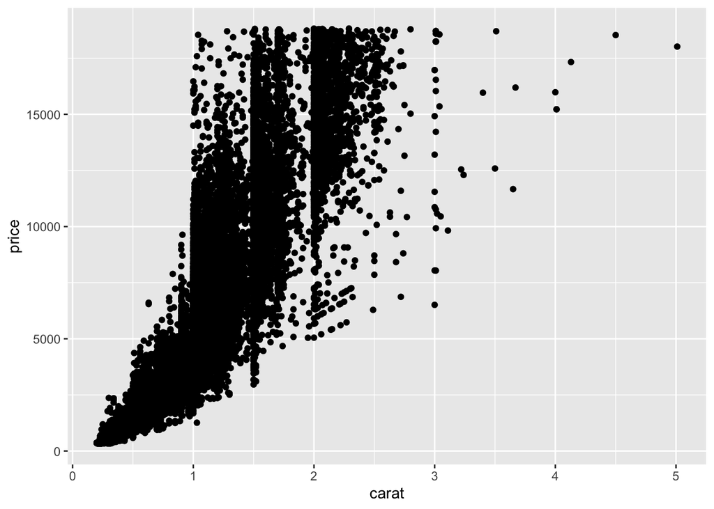

```r
diamonds_working %>%
  ggplot() +
  aes(x = carat, y = price) +
  geom_point()
```

* Clear positive correlation

#### 5

##### i

```r
unique(diamonds_working$cut)
```

```
## [1] "Ideal"     "Premium"   "Good"      "Very Good" "Fair"
```

```r
unique(diamonds_working$clarity)
```

```
## [1] "SI2"  "SI1"  "VS1"  "VS2"  "VVS2" "VVS1" "I1"   "IF"
```

```r
unique(diamonds_working$color)
```

```
## [1] "E" "I" "J" "H" "F" "G" "D"
```

- cut = 4 Dummy variables
- clarity = 7 Dummy variables
- Colour = 6 Dummy variables

##### ii

```r
library(fastDummies)
```

```r
dummy_cols(diamonds_working, select_columns = c("cut", "clarity", "color"), remove_first_dummy = T, remove_selected_columns = T)
```

```
## # A tibble: 53,940 x 21
##    carat depth table price cut_Good cut_Ideal cut_Premium `cut_Very Good`
##    <dbl> <dbl> <dbl> <dbl>    <int>     <int>       <int>           <int>
##  1 0.23   61.5    55   326        0         1           0               0
##  2 0.21   59.8    61   326        0         0           1               0
##  3 0.23   56.9    65   327        1         0           0               0
##  4 0.290  62.4    58   334        0         0           1               0
##  5 0.31   63.3    58   335        1         0           0               0
##  6 0.24   62.8    57   336        0         0           0               1
##  7 0.24   62.3    57   336        0         0           0               1
##  8 0.26   61.9    55   337        0         0           0               1
##  9 0.22   65.1    61   337        0         0           0               0
## 10 0.23   59.4    61   338        0         0           0               1
## # … with 53,930 more rows, and 13 more variables: clarity_IF <int>,
## #   clarity_SI1 <int>, clarity_SI2 <int>, clarity_VS1 <int>, clarity_VS2 <int>,
## #   clarity_VVS1 <int>, clarity_VVS2 <int>, color_E <int>, color_F <int>,
## #   color_G <int>, color_H <int>, color_I <int>, color_J <int>
```

- Correct number of dummy columns

#### 6

```r
library(broom)
library(ggfortify)
```

##### i

```r
model_diamonds1 <- lm(price ~ carat, data = diamonds_working)

summary(model_diamonds1)
```

```
##
## Call:
## lm(formula = price ~ carat, data = diamonds_working)
##
## Residuals:
##      Min       1Q   Median       3Q      Max
## -18585.3   -804.8    -18.9    537.4  12731.7
##
## Coefficients:
##             Estimate Std. Error t value Pr(>|t|)
## (Intercept) -2256.36      13.06  -172.8   <2e-16 ***
## carat        7756.43      14.07   551.4   <2e-16 ***
## ---
## Signif. codes:  0 '***' 0.001 '**' 0.01 '*' 0.05 '.' 0.1 ' ' 1
##
## Residual standard error: 1549 on 53938 degrees of freedom
## Multiple R-squared:  0.8493, Adjusted R-squared:  0.8493
## F-statistic: 3.041e+05 on 1 and 53938 DF,  p-value: < 2.2e-16
```

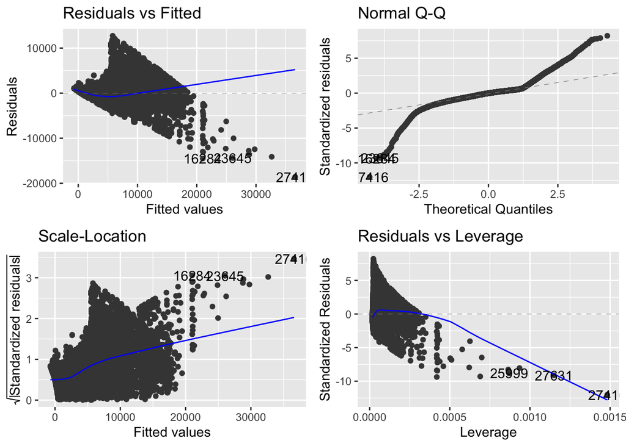

```r
autoplot(model_diamonds1)
```

* Low p value, High R squared = good stuff

- Res vs fitted = line rises to the right, not good
- Q-Q = looks odd
- Scale-location = line rises to right, not good

##### ii

```r
model_diamonds2 <- lm(log(price) ~ carat, data = diamonds_working)

summary(model_diamonds2)
```

```
##
## Call:
## lm(formula = log(price) ~ carat, data = diamonds_working)
##
## Residuals:
##     Min      1Q  Median      3Q     Max
## -6.2844 -0.2449  0.0335  0.2578  1.5642
##
## Coefficients:
##             Estimate Std. Error t value Pr(>|t|)
## (Intercept) 6.215021   0.003348    1856   <2e-16 ***
## carat       1.969757   0.003608     546   <2e-16 ***
## ---
## Signif. codes:  0 '***' 0.001 '**' 0.01 '*' 0.05 '.' 0.1 ' ' 1
##
## Residual standard error: 0.3972 on 53938 degrees of freedom
## Multiple R-squared:  0.8468, Adjusted R-squared:  0.8468
## F-statistic: 2.981e+05 on 1 and 53938 DF,  p-value: < 2.2e-16
```

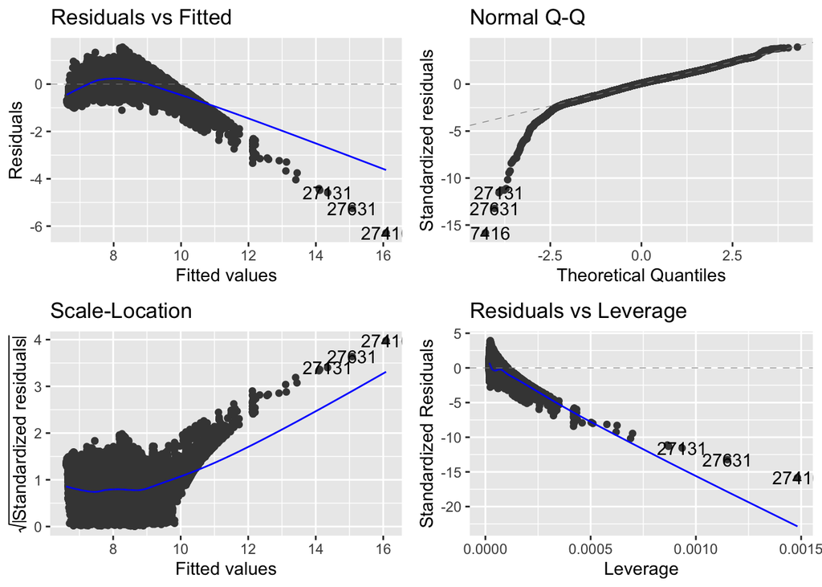

```r
autoplot(model_diamonds2)
```

- p value and r squared still good
- graphs look worse!

```r
model_diamonds3 <- lm(price ~ log(carat), data = diamonds_working)

summary(model_diamonds3)
```

```
##
## Call:
## lm(formula = price ~ log(carat), data = diamonds_working)
##
## Residuals:
##     Min      1Q  Median      3Q     Max
## -6137.4 -1495.1  -328.3  1141.9 12075.3
##
## Coefficients:
##             Estimate Std. Error t value Pr(>|t|)
## (Intercept)  6237.84      10.73   581.2   <2e-16 ***
## log(carat)   5836.02      15.21   383.8   <2e-16 ***
## ---
## Signif. codes:  0 '***' 0.001 '**' 0.01 '*' 0.05 '.' 0.1 ' ' 1
##
## Residual standard error: 2066 on 53938 degrees of freedom
## Multiple R-squared:  0.7319, Adjusted R-squared:  0.7319
## F-statistic: 1.473e+05 on 1 and 53938 DF,  p-value: < 2.2e-16
```

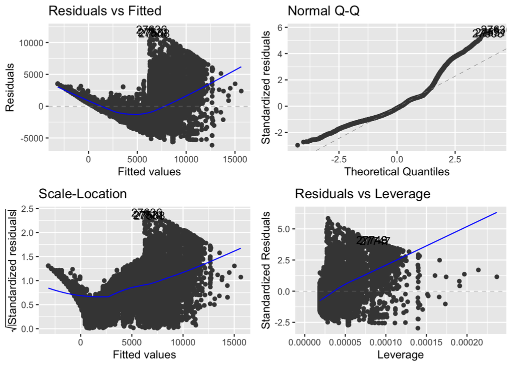

```r
autoplot(model_diamonds3)
```

- p value and r squared still good
- graphs look worse!

```r
model_diamonds4 <- lm(log(price) ~ log(carat), data = diamonds_working)

summary(model_diamonds4)
```

```
##
## Call:
## lm(formula = log(price) ~ log(carat), data = diamonds_working)
##
## Residuals:
##      Min       1Q   Median       3Q      Max
## -1.50833 -0.16951 -0.00591  0.16637  1.33793
##
## Coefficients:
##             Estimate Std. Error t value Pr(>|t|)
## (Intercept) 8.448661   0.001365  6190.9   <2e-16 ***
## log(carat)  1.675817   0.001934   866.6   <2e-16 ***
## ---
## Signif. codes:  0 '***' 0.001 '**' 0.01 '*' 0.05 '.' 0.1 ' ' 1
##
## Residual standard error: 0.2627 on 53938 degrees of freedom
## Multiple R-squared:  0.933,  Adjusted R-squared:  0.933
## F-statistic: 7.51e+05 on 1 and 53938 DF,  p-value: < 2.2e-16
```

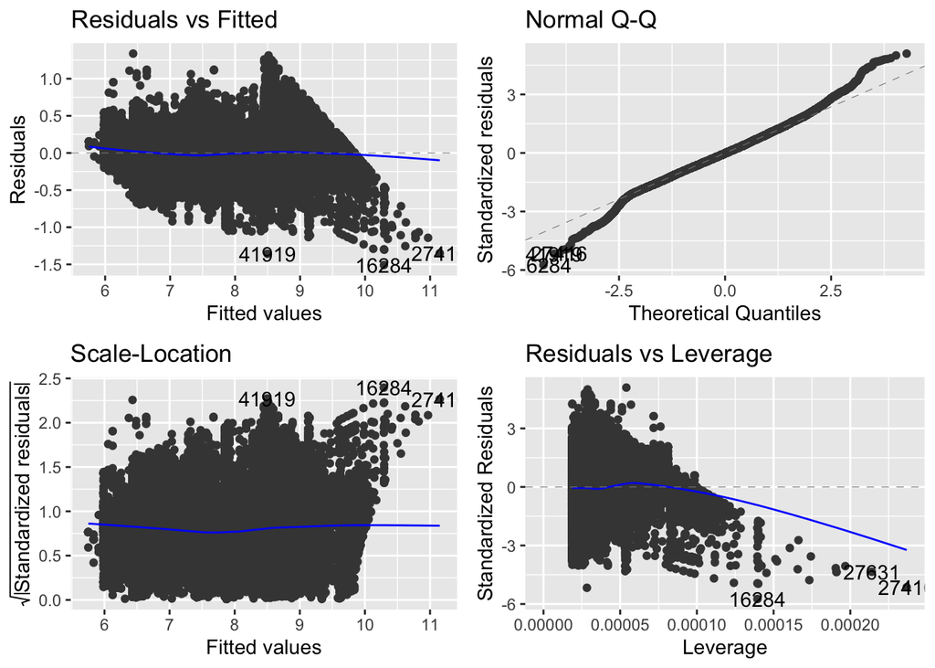

```r
autoplot(model_diamonds4)
```

##### iii

```r
model_diamonds5 <- lm(log(price) ~ log(carat) + cut, data = diamonds_working)

summary(model_diamonds5)
```

```
##
## Call:
## lm(formula = log(price) ~ log(carat) + cut, data = diamonds_working)
##
## Residuals:
##      Min       1Q   Median       3Q      Max
## -1.52247 -0.16484 -0.00587  0.16087  1.38115
##
## Coefficients:
##              Estimate Std. Error t value Pr(>|t|)
## (Intercept)  8.200125   0.006343 1292.69   <2e-16 ***
## log(carat)   1.695771   0.001910  887.68   <2e-16 ***
## cutGood      0.163245   0.007324   22.29   <2e-16 ***
## cutIdeal     0.317212   0.006632   47.83   <2e-16 ***
## cutPremium   0.238217   0.006716   35.47   <2e-16 ***
## cutVery Good 0.240753   0.006779   35.52   <2e-16 ***
## ---
## Signif. codes:  0 '***' 0.001 '**' 0.01 '*' 0.05 '.' 0.1 ' ' 1
##
## Residual standard error: 0.2545 on 53934 degrees of freedom
## Multiple R-squared:  0.9371, Adjusted R-squared:  0.9371
## F-statistic: 1.607e+05 on 5 and 53934 DF,  p-value: < 2.2e-16
```

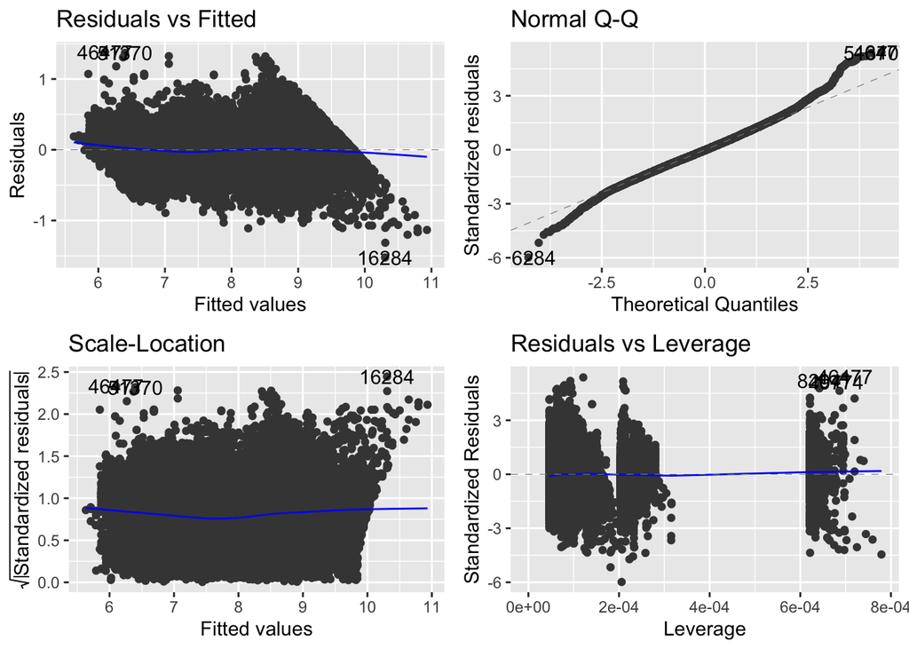

```r
autoplot(model_diamonds5)
```

```r
model_diamonds6 <- lm(log(price) ~ log(carat) + clarity, data = diamonds_working)

summary(model_diamonds6)
```

```
##
## Call:
## lm(formula = log(price) ~ log(carat) + clarity, data = diamonds_working)
##
## Residuals:
##      Min       1Q   Median       3Q      Max
## -0.97521 -0.12085  0.01048  0.12561  1.85854
##
## Coefficients:
##             Estimate Std. Error t value Pr(>|t|)
## (Intercept) 7.768115   0.006940 1119.25   <2e-16 ***
## log(carat)  1.806424   0.001514 1193.23   <2e-16 ***
## clarityIF   1.114625   0.008376  133.07   <2e-16 ***
## claritySI1  0.624558   0.007163   87.19   <2e-16 ***
## claritySI2  0.479658   0.007217   66.46   <2e-16 ***
## clarityVS1  0.820461   0.007306  112.30   <2e-16 ***
## clarityVS2  0.775248   0.007197  107.72   <2e-16 ***
## clarityVVS1 1.028298   0.007745  132.77   <2e-16 ***
## clarityVVS2 0.979221   0.007529  130.05   <2e-16 ***
## ---
## Signif. codes:  0 '***' 0.001 '**' 0.01 '*' 0.05 '.' 0.1 ' ' 1
##
## Residual standard error: 0.1888 on 53931 degrees of freedom
## Multiple R-squared:  0.9654, Adjusted R-squared:  0.9654
## F-statistic: 1.879e+05 on 8 and 53931 DF,  p-value: < 2.2e-16
```

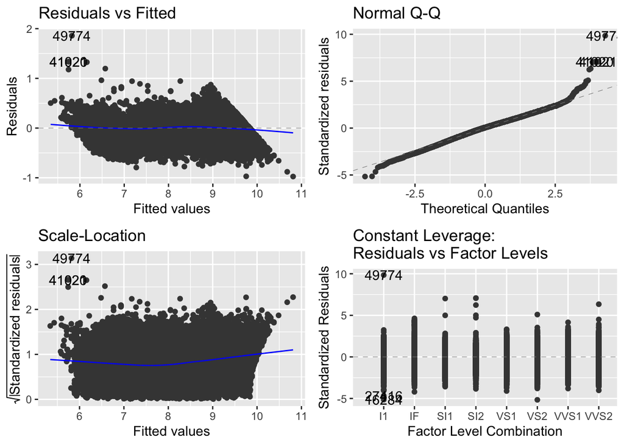

```r
autoplot(model_diamonds6)
```

```r
model_diamonds7 <- lm(log(price) ~ log(carat) + color, data = diamonds_working)

summary(model_diamonds7)
```

```
##
## Call:
## lm(formula = log(price) ~ log(carat) + color, data = diamonds_working)
##
## Residuals:
##      Min       1Q   Median       3Q      Max
## -1.49987 -0.14888  0.00257  0.15316  1.27815
##
## Coefficients:
##              Estimate Std. Error  t value Pr(>|t|)
## (Intercept)  8.572034   0.003051 2809.531  < 2e-16 ***
## log(carat)   1.728631   0.001814  952.727  < 2e-16 ***
## colorE      -0.025460   0.003748   -6.793 1.11e-11 ***
## colorF      -0.034455   0.003773   -9.132  < 2e-16 ***
## colorG      -0.055399   0.003653  -15.166  < 2e-16 ***
## colorH      -0.189859   0.003917  -48.468  < 2e-16 ***
## colorI      -0.286928   0.004383  -65.467  < 2e-16 ***
## colorJ      -0.425038   0.005417  -78.466  < 2e-16 ***
## ---
## Signif. codes:  0 '***' 0.001 '**' 0.01 '*' 0.05 '.' 0.1 ' ' 1
##
## Residual standard error: 0.2372 on 53932 degrees of freedom
## Multiple R-squared:  0.9454, Adjusted R-squared:  0.9454
## F-statistic: 1.333e+05 on 7 and 53932 DF,  p-value: < 2.2e-16
```

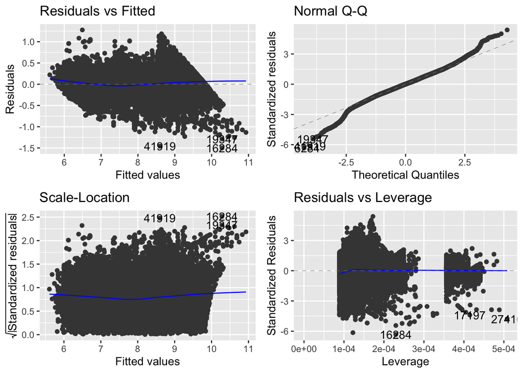

```r
autoplot(model_diamonds7)
```

- ALl look good graph wise
- All have low p values and high r squared values
- Clarity has the highest R Squared value so is the best categorical predictor

##### iv

- Clarity
- reference level = 7.768115
- Clarity of “IF” shows greatest difference (increase) in price from reference level. Makes sense since it is the “best” clarity

# Extension

#### 7

```r
model_diamonds8 <- lm(log(price) ~ log(carat) + clarity + log(carat):clarity, data = diamonds_working)

summary(model_diamonds8)
```

```
##
## Call:
## lm(formula = log(price) ~ log(carat) + clarity + log(carat):clarity,
##     data = diamonds_working)
##
## Residuals:
##      Min       1Q   Median       3Q      Max
## -0.92773 -0.12104  0.01212  0.12465  1.51830
##
## Coefficients:
##                        Estimate Std. Error t value Pr(>|t|)
## (Intercept)            7.808102   0.007223 1080.98   <2e-16 ***
## log(carat)             1.528106   0.014944  102.25   <2e-16 ***
## clarityIF              1.122732   0.011381   98.65   <2e-16 ***
## claritySI1             0.587556   0.007465   78.71   <2e-16 ***
## claritySI2             0.438797   0.007486   58.62   <2e-16 ***
## clarityVS1             0.790989   0.007721  102.45   <2e-16 ***
## clarityVS2             0.723109   0.007530   96.03   <2e-16 ***
## clarityVVS1            1.007591   0.009506  106.00   <2e-16 ***
## clarityVVS2            0.968426   0.008359  115.85   <2e-16 ***
## log(carat):clarityIF   0.337116   0.017593   19.16   <2e-16 ***
## log(carat):claritySI1  0.288214   0.015254   18.89   <2e-16 ***
## log(carat):claritySI2  0.258795   0.015437   16.76   <2e-16 ***
## log(carat):clarityVS1  0.300307   0.015395   19.51   <2e-16 ***
## log(carat):clarityVS2  0.250187   0.015237   16.42   <2e-16 ***
## log(carat):clarityVVS1 0.301955   0.016317   18.51   <2e-16 ***
## log(carat):clarityVVS2 0.321665   0.015717   20.47   <2e-16 ***
## ---
## Signif. codes:  0 '***' 0.001 '**' 0.01 '*' 0.05 '.' 0.1 ' ' 1
##
## Residual standard error: 0.1877 on 53924 degrees of freedom
## Multiple R-squared:  0.9658, Adjusted R-squared:  0.9658
## F-statistic: 1.014e+05 on 15 and 53924 DF,  p-value: < 2.2e-16
```

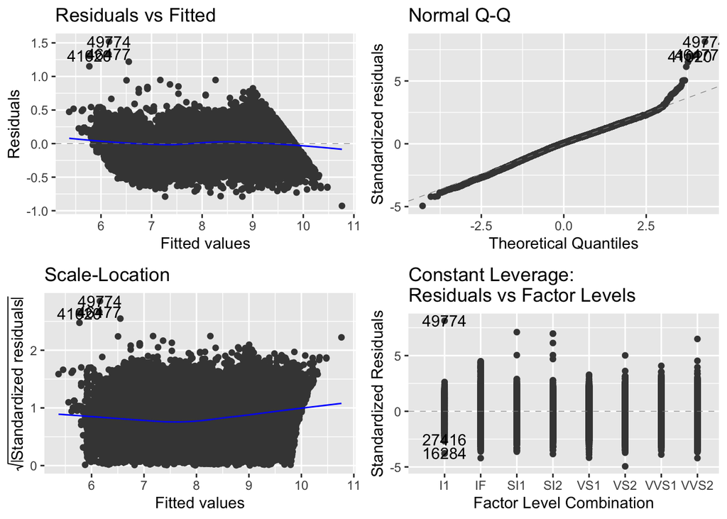

```r
autoplot(model_diamonds8)
```

- Yes it is statistically justified
- It also makes sense that a diamond that has a better clarity and a has more carrots will have a higher price.

##### 8

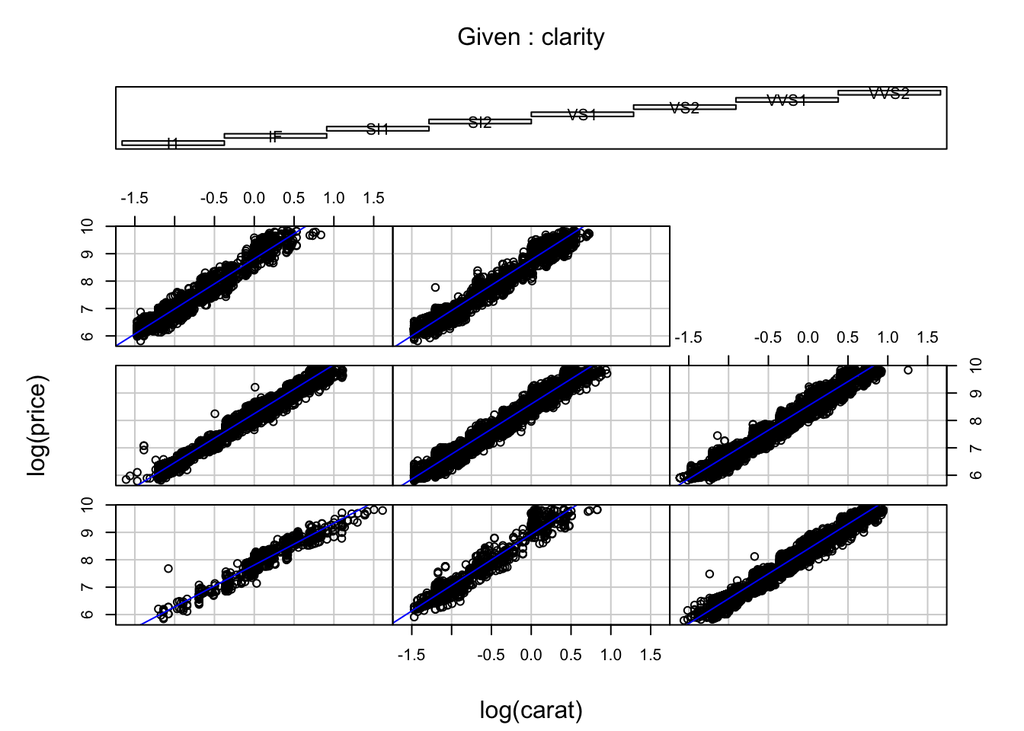

```r
coplot(log(price) ~ log(carat)|clarity,
       panel = function(x, y, ...){
         points(x, y)
         abline(lm(y ~ x), col = "blue")
       },
       data = diamonds_working)
```

- This shows that as log(carat) increases, the log(price) increases for all clarities.
- Perhaps shows that the carat doesn’t have to be as high for the price to be high for the better clarities.